# Application of stochastic character mapping to reconstruct the origin of somatic mutations

Michael Tassia

2026-02-05

## Introduction

To infer the origin of somatic mutations using stochastic character mapping (SCM; algorithm description can be found in [Bollback 2006](https://pubmed.ncbi.nlm.nih.gov/16504105/)), we use the comparative phylogenetic toolkit `phytools` in R. Comparative phylogenetics has a long history within R, and the modular design of `phytools` (and its dependencies) make it simple to implement SCM for a single somatic single nucleotide variant (SNV).

## Methods

First, the following libraries are required for loading data and performing SCM. These libraries are included in the conda environment specified in [`scm_env.yaml`].

```r
# Required packages
library(phytools)
library(tidyverse)
library(data.table)
library(vcfR)
library(pbapply)
library(snow)
library(RColorBrewer)
```

Additionally, we will load custom functions for reading data and performing SCM from the `scm_functions.R` script.

```r
source("scm_functions.R")
```

### Load data

There are three fundamental parameters to SCM:

1. A phylogenetic tree describing the relationship among all samples (cells), with branch lengths measured in substitutions per site.
2. Substitution matrix ($\textbf{Q}$) describing the rates of change between character states (e.g., unphased genotype states), jointly inferred with the phylogenetic tree (see [CellPhy manuscript](https://github.com/amkozlov/cellphy))
3. Genotype state priors for each sample (cell)

We will load (and visualize) each of these components below.

#### Phylogenetic tree

The phylogeny needs to be rooted such that the root node best reflects the germline state; this allows for empirical priors for the root node if germline states are known and/or uncertain. Here, we use a matched normal (`OUTGROUP`) as the outgroup to define the root. The scale bar presented in the figure below has units of *substitutions per site*.

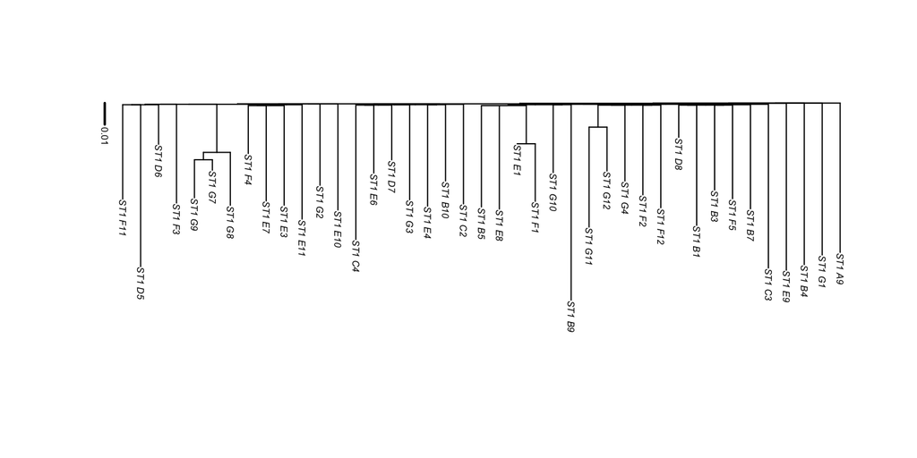

```r
# Read tree
tree <- read.tree(file = "data/ST1.nwk",) %>%
  root(outgroup = "OUTGROUP", resolve.root = TRUE) %>%
  drop.tip("OUTGROUP")

# Plot tree with scalebar (sub/site)
plot.phylo(x = ladderize(tree),
         direction = "downwards",
         color = "black",
         cex = 0.5,
         fsize = 0.8,
         lwd = 2)
add.scale.bar(length = 0.01,
              lwd = 2,
              x = 0,
              y = max(nodeHeights(tree)), cex = 0.5)
```

#### Substitution model

The substitution model file output by [CellPhy](https://github.com/amkozlov/cellphy) contains information on the relative rates of change between unphased diploid genotypes (A/A, A/C, A/G, A/T, C/C, C/G, C/T, G/G, G/T, T/T) and the relative frequencies for each genotype state. The formatting for this file (as output by `CellPhy` version `0.9.2`) is discussed in [this thread](https://groups.google.com/d/msgid/raxml/16f92bbc-20c6-4559-a42e-c949c35289d1n%40googlegroups.com). From these two matrices, we can generate the $Q_{10}$ substitution matrix for the 10 unphased diploid genotype states, which is required for SCM.

```r
# Read substitution model
q <- read_cellphy_model("data/ST1.Q.txt")

# View table
round(q, 3)
```

```
##        AA     CC     GG     TT     AC     AG     AT     CG     CT     GT
## AA -0.144  0.001  0.001  0.001  0.016  0.088  0.033  0.001  0.001  0.001
## CC  0.001 -0.118  0.001  0.001  0.016  0.001  0.001  0.009  0.088  0.001
## GG  0.001  0.001 -0.118  0.001  0.001  0.088  0.001  0.009  0.001  0.016
## TT  0.001  0.001  0.001 -0.142  0.001  0.001  0.033  0.001  0.088  0.016
## AC  0.362  0.518  0.001  0.001 -1.070  0.035  0.029  0.022  0.101  0.001
## AG  0.471  0.001  0.647  0.001  0.008 -1.192  0.022  0.017  0.001  0.024
## AT  0.548  0.001  0.001  0.525  0.021  0.067 -1.252  0.001  0.067  0.020
## CG  0.001  0.269  0.258  0.001  0.021  0.068  0.001 -0.705  0.066  0.021
## CT  0.001  0.679  0.001  0.454  0.024  0.001  0.022  0.016 -1.207  0.008
## GT  0.001  0.001  0.493  0.344  0.001  0.103  0.029  0.022  0.035 -1.028
```

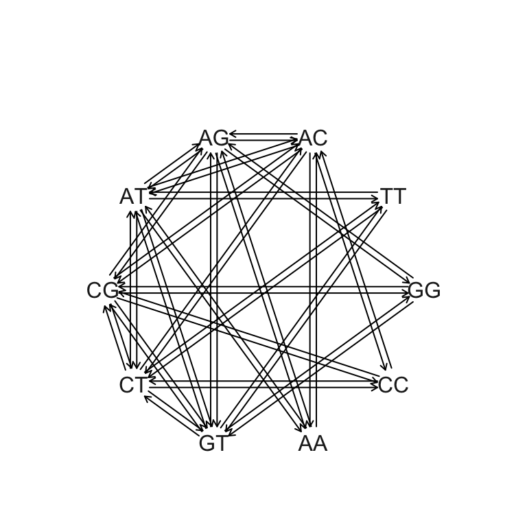

```r
# For visualization purposes, we will replace all "near-zero" values with zeroes
# and remove all vectors with zero rates
q.plot <- q
q.plot[which(q.plot == 0.001)] <- 0
plot.Qmatrix(x = q.plot,
             show.zeros = FALSE,
             text = FALSE,
             signif = 2)
```

#### Genotype state priors

Next we will load a multi-sample VCF of somatic variants, where all tips in `tree` are represented as samples in the VCF. From this VCF, we can compute scaled probabilities from the Phred-scaled genotype likelihoods (`PL` FORMAT field). Here, we are using a small subset of variants for demonstration purposes only (these are somatic variants with > 1 origin on the tree).

```r
# Read VCF
vcf <- read.vcfR("data/ST1.scm_vars.vcf.gz", verbose = FALSE)

# Compile somatic SNV genotype priors
gt_states <- compile_gt_states.snp(vcf)
```

```
## [1] "Reading vcf data..."
```

```
## [1] "Computing genotype probabilities..."
## [1] "Assembling genotype state matrices for SNPs..."
```

The function `compile_gt_states.snp()` reads the `vcfR` object and outputs a list of of data.tables, where each data.table can be accessed either through list indexing (e.g., `gt_states[[1]]`). Alternatively, an index can be accessed by its `<chrom>_<pos>` string:

```r
# Print tibble
tibble(gt_states[["chr9_125226000"]]) %>%
  select(!c(locus)) %>%
  mutate(AA = round(AA, 3),
         TT = round(TT, 3),
         AT = round(AT, 3))
```

```
## # A tibble: 41 × 11
##    clone      AA    CC    GG    TT    AC    AG    AT    CG    CT    GT
##    <chr>   <dbl> <dbl> <dbl> <dbl> <dbl> <dbl> <dbl> <dbl> <dbl> <dbl>
##  1 ST1_A9      0     0     0 0.998     0     0 0.002     0     0     0
##  2 ST1_B1      0     0     0 0         0     0 1         0     0     0
##  3 ST1_B10     0     0     0 1         0     0 0         0     0     0
##  4 ST1_B3      0     0     0 1         0     0 0         0     0     0
##  5 ST1_B4      0     0     0 0.996     0     0 0.004     0     0     0
##  6 ST1_B5      0     0     0 1         0     0 0         0     0     0
##  7 ST1_B7      0     0     0 0.998     0     0 0.002     0     0     0
##  8 ST1_B9      0     0     0 0.999     0     0 0.001     0     0     0
##  9 ST1_C2      0     0     0 1         0     0 0         0     0     0
## 10 ST1_C3      0     0     0 0         0     0 1         0     0     0
## # ℹ 31 more rows
```

### Perform SCM

To perform SCM for a single somatic SNP, we will use the wrapper function `runSCM_single()`. In this example here, we will run SCM for 1000 replicates on the locus `chr9_125226000` using a naive root state prior.

```r
scm <- runSCM_single(locus_str = "chr9_125226000",
              tree = tree,
              gt_state_list = gt_states,
              Qmat = q,
              reps = 1000,
              cores = 6)
```

```
## [1] "Performing stochastic character mapping on chr9_125226000."
## [1] "Cores: 6"
## [1] "Replicates: 1000"
## [1] "Reduced Qmatrix: FALSE"
```

Because we requested 1000 replicates and 6 cores, the wrapper rounded up to the nearest multiple of 6 (i.e., 1002 replicates) and distributed the SCM replicates across 6 parallel R processes. The wrapper runs $N$ instances of the `phytools` function `make.simmap()`, where $N$ is the number of requested cores.

Below, we will summarize across the posterior distribution to infer the number of state changes on the tree:

```r
summary(scm)
```

```
## 1002 trees with a mapped discrete character with states:
##  AT, TT
##
## trees have 2.01596806387226 changes between states on average
##
## changes are of the following types:
##      AT,TT    TT,AT
## x->y     0 1.994012
##
## mean total time spent in each state is:
##            AT       TT    total  AA  CC  GG  AC  AG  CG           CT
## raw  0.064789 1.783232 1.848295   0   0   0   0   0   0 0.0002075417
## prop      Inf      Inf      Inf NaN NaN NaN NaN NaN NaN          NaN
##                GT
## raw  6.599124e-05
## prop          NaN
```

Finally, we can plot state transitions (as black diamonds) along edges where the genotype states shift from ancestor to descendent and both genotype calls have posterior probabilities $\ge$ 0.95.

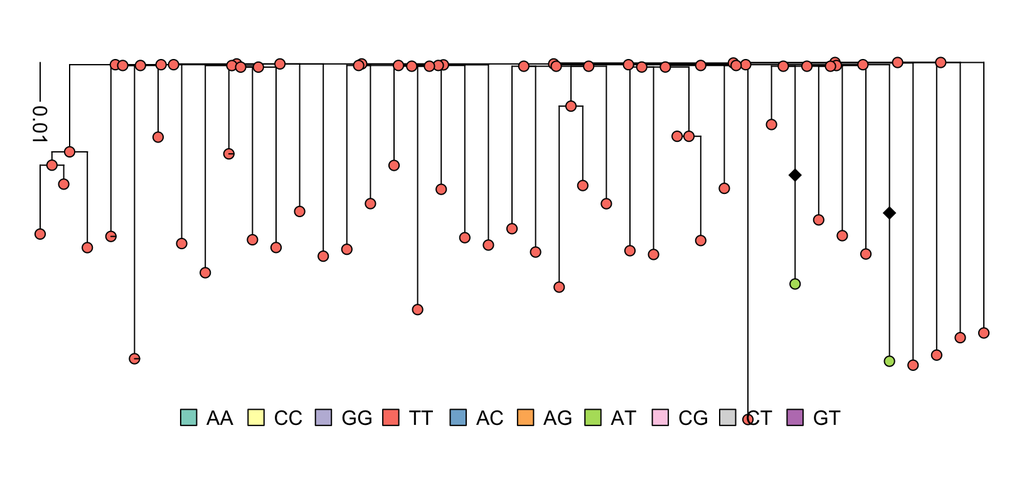

```r
scm_summary <- summarise_scm.snp(scm,
                                 plot = T,
                                 legend = T,
                                 PPthreshold = 0.95)
```